# DV Assignment 2, Part 1: Beyond the Benchmark

Group 5: Danielius Rimas, Robert Rotaru, Nicusor Simionescu

2026-10-09

## Research question

#### RQ

Among primary schools in Amsterdam in 2024-2025, which schools show stronger attainment in mathematics versus reading (or the other way around), compared with similarly disadvantaged schools?

#### Type of Analysis

We will compare each school’s mathematics 1S and reading 2F attainment with the national relationship between these two measures, estimated among Dutch schools with a similar schoolweging. The fitted line is a descriptive benchmark, rather than a model for forecasting future outcomes. Our research question is analytical: the goal is to identify schools whose subject profiles differ noticeably from the national pattern.

#### Target Audience

This information is valuable for the educational inspectorate of Amsterdam and possibly local school boards.

## Exploratory process

We first checked which municipalities had enough schools for comparisons. Amsterdam had 203 school locations in the initial municipality count. We then computed 1S mathematics and 2F reading attainment, replacing suppressed counts (`<5`) with 2.5 for this first analysis.

```r
referentieniveaus |>
  distinct(
    INSTELLINGSCODE,
    VESTIGINGSCODE,
    GEMEENTENAAM
  ) |>
  count(
    GEMEENTENAAM,
    sort = TRUE,
    name = "n_schools"
  ) |>
  slice_head(n = 10)
```

```
## # A tibble: 10 × 2
##    GEMEENTENAAM  n_schools
##    <chr>             <int>
##  1 Amsterdam           203
##  2 Rotterdam           167
##  3 's-Gravenhage       138
##  4 Utrecht             101
##  5 Almere               74
##  6 Apeldoorn            63
##  7 Groningen            56
##  8 Tilburg              54
##  9 Enschede             53
## 10 Eindhoven            52
```

Mathematics 1S and reading 2F are different achievement thresholds, so their raw percentages cannot be interpreted as interchangeable. Our first exploratory approach subtracted separate national subject benchmarks within school-weighting groups. That exposed schools with different relative strengths, but did not directly show whether their *combination* of mathematics and reading outcomes was unusual. The final visualization therefore uses a fitted national mathematics–reading relationship and prediction intervals, estimated within school-weighting bands.

### Exploratory graph: differences from separate subject benchmarks

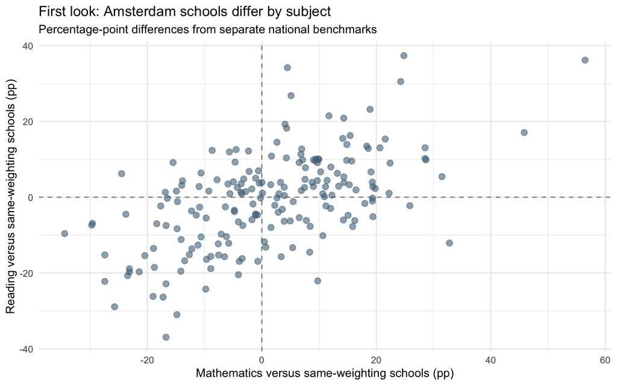

This first plot revealed different achievement profiles but did not isolate schools with *atypical reading attainment conditional on their mathematics attainment*. The final visualization addresses that question directly.

## Explanatory visualization

We resolved an initial school-identifier mismatch: 21 Amsterdam locations that had been excluded by an institution-level uniqueness filter were matched to the corresponding school-weighting clusters. This raises Amsterdam coverage from 169 to 190 locations with usable results (out of 203 originally observed).

**How to read it.** The fitted line is the national relationship between mathematics 1S and reading 2F attainment. The inner light-grey area is a 90% prediction interval for an individual school, and the wider darker-grey area is the 95% interval. Grey circles are within 90%; light-blue shapes fall outside 90% but remain inside 95%; dark-blue shapes fall outside 95%. Diamonds are relatively reading-leaning (above the upper boundary), while triangles are relatively maths-leaning (below the lower boundary). Marker size reflects pupils tested.

The slider defaults to the school-weighting band containing the most 95%-level departures and excludes bands without such departures from its focused choices. **ALL DATA** remains available for context, but its fitted line uses all Dutch schools without conditioning on school weighting. Small bands with fewer than 20 national schools are omitted from the band-by-band comparisons.

[interactive chart not shown]

### Main finding and interpretation

In school-weighting band 22, 1 of 26 Amsterdam schools fall outside the 95% national prediction interval, with 0 additional schools outside 90% but inside 95%.

A school above the range has higher *reading* attainment than the national relationship would predict from its mathematics result, while a school below has relatively stronger *mathematics*. These are **descriptive flags**, not diagnoses of school quality or proof of subject-specific teaching effects. Even under a well-fitting model, some observations fall outside prediction intervals by chance, especially when many schools are examined.

**Robustness and limitations.** The intervals assume a linear model and roughly stable residual variation within the compared group. The analysis replaces suppressed pupil counts (`<5`) with 2.5; repeating with 1 and 4 is needed before making strong claims. Scores can also vary by doorstroomtoets provider. Of 203 Amsterdam locations, 190 have usable attainment data and a verified location-level school-weighting match; five lack school-weighting records, and eight have no mathematics or reading test participants. The 21 locations previously excluded because of shared institution codes are included through an audited crosswalk. The national reference still excludes ambiguous multi-location institutions outside Amsterdam. The chart is most useful for selecting schools for follow-up, not ranking their overall quality.

```r
lint(rstudioapi::getSourceEditorContext()$path)
```